# Hw1_Sangwon_JI

2022-09-09

# **Question 1) REI Camp & Hike Product**

## **Osprey Archeon 30 Pack - Men’s**

### **Link for the product**

https://www.rei.com/product/164401/osprey-archeon-30-pack-mens

### **Image of the Bag**

[figure not shown]

**Osprey Archeon 30 Pack**

### **Description of the product**

> **Made for hiking, commuting and traveling, the streamlined men’s Osprey Archeon 30 pack hauls your must-haves wherever the day takes you—from the natural world to the urban jungle.**

### **Features**

- Front zipper access makes it easy to stash and retrieve your stuff
- Constructed with Global Recycle Standard (GRS)-certified recycled materials and a C0 PFC-free durable water repellent (DWR) finish that sloughs off moisture
- GRS ensures accurate content claims and good working conditions while minimizing harmful environmental and chemical impacts
- Trail-specific additions include an internal reservoir sleeve, dual ice axe loops and webbing lash points; reservoir sleeve can fit up to a 3L reservoir (not included)
- Included removable raincover keeps your gear dry if the weather turns
- Dual-access side pockets secure your water bottles and snacks; dual low-profile, stretch-woven hipbelt stash pockets hold the small stuff
- HDPE framesheet and dual profiled aluminum alloy stays spread the load across the entire back panel
- Adjustable harness helps you get a perfect fit
- Mesh-covered bumped foam allows for ventilation while keeping the load close to body

### **Technical Specs**

| **Categories** | **Descriptions** |
| --- | --- |
| **Best Use** | Casual Hiking |
| **Bag style** | Backpack |
| **Frame Type** | Internal Frame |
| **Gear Capacity (L)** | 30 liters |
| **Gear Capacity (cu. in.)** | 1,831 cubic inches |
| **Weight** | 3 lbs. 15.5 oz. |
| **Fits Torso Length (in.)** | 17-22 inches |
| **Fits Waist/Hips** | 25-52 inches |
| **Material(s)** | Main: 940x1880-denier recycled nylon (bluesign® approved); lining: 210-denier recycled nylon; mesh-covered bumped foam |
| **Frame Material** | HDPE framesheet |
| **Number of Stays** | 2 |
| **Pack Access** | Top/Front |
| **Number of Exterior Pockets** | 5 + main compartment |
| **Hipbelt** | Yes |
| **Hipbelt Pockets** | Yes |
| **Raincover Included** | Yes |
| **Reservoir Compatible** | Yes |
| **Dimensions** | 26 x 12 x 10 inches |
| **Gender** | Men’s |
| **Sustainability** | Contains recycled materials Contains materials that meet the bluesign® criteria |

# **Question 2) Cooking Recipe**

## **Buttermilk French Toast**

### **Link of the recipe**

https://www.epicurious.com/recipes/food/views/buttermilk-french-toast-358115

##### **Editor’s Note**

*This recipe was originally published in November 2008.*

### **How the meal will look when it’s done**

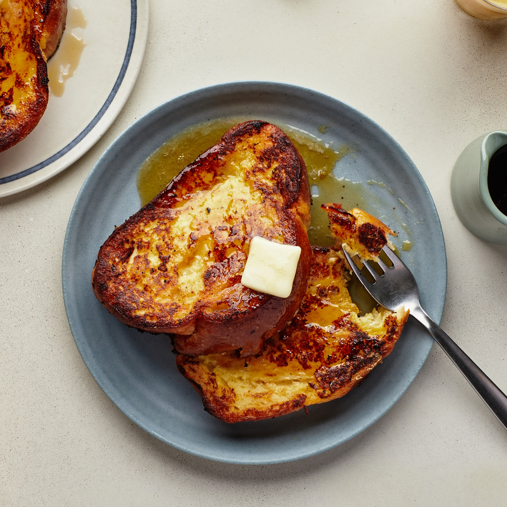

**Buttermilk French Toast** [^1]

### **Ingredients**

##### `Makes 4 Servings`

- 1 ½ cups well-shaken buttermilk
- 4 large eggs
- 3 tablespoons sugar
- ¼ teaspoon salt
- 12(½-inch-thick) slices challah (from a 1-pound loaf; not end slices)
- 4 ½ tablespoons unsalted butter; divided

#### **Accompaniment**

- Warm maple syrup

#### **Cooking Steps**

##### **Step 1**

Preheat oven to 200°F.

##### **Step 2**

Whisk together buttermilk, eggs, sugar, and salt in a bowl. Pour into a large 4-sided sheet pan, then add bread in 1 layer and soak, turning occasionally, until bread has absorbed all liquid but is not falling apart, about 20 minutes.

##### **Step 3**

Heat 1½ tablespoon butter in a 12-inch nonstick skillet over medium-high heat until foam subsides. Transfer 4 bread slices with a slotted spatula to skillet and cook, turning once, until slightly puffed and golden brown, about 3 minutes total. Transfer to a large shallow baking pan and keep warm in oven. Cook remaining bread in 2 batches, adding 1½ tablespoon butter between batches.

# **Question 3)Euclidean Distance**

The **Euclidean distance** between points **p** and **q** is the length of the **line segment** connecting them ($\overline{pq}$).

In **Cartesian coordinates**, if **p** = ($p_{1},p_{2},\dots,p_{n}$) and **q** = ($q_{1},q_{2},\dots,q_{n}$) are two points in **Euclidean n-space**, then the distance (d) from **p** to **q**, or from **q** to **p** is given by the **Pythagorean formula**.

$d$(**p**,**q**) = $d$(**q**,**p**) = $\sqrt{(q_{1}-p_{1})^2 + (q_{2}-p_{2})^2+\dots+(q_{n}-p_{n})^2} = \sqrt{\displaystyle\sum_{i=1}^{n}(q_{i}-p_{i})^2}$.

The position of a point in a Euclidean *n*-space is a **Euclidean vector**. So, **p** and **q** may be represented as Euclidean vectors, starting from the origin of the space (initial point) with their tips (terminal points) ending at the two points. The **Euclidean norm**, or **Euclidean length**, or **magnitude** of a vector measures the length of the vector.

$\|p\| = \sqrt{p_1^2+p_2^2+\dots+p_n^2} = \sqrt{p.p}$,

where the last expression involves the **dot product**.

[^1]: Photo by Isa Zapata, Prop Styling by Stephanie De Luca, Food Styling by Yekaterina Boystova